# PCIT-CoS-Waitlist RCT Paper 1:CCQ Caregiving Helplessness, Controlling for ASD

Nancy Briggs

05 JAN 2021

### CCQ Caregiving Helplessness Adjusting for ASD

#### Descriptives

| asdcase | group | time | n | mean | sd | median | min | max |
| --- | --- | --- | --- | --- | --- | --- | --- | --- |
| 0 | 1 | 1 | 24 | 1.738 | 0.623 | 1.500 | 1.000 | 3.143 |
| 0 | 1 | 2 | 17 | 1.378 | 0.558 | 1.143 | 1.000 | 3.143 |
| 0 | 1 | 3 | 13 | 1.352 | 0.427 | 1.143 | 1.000 | 2.429 |
| 0 | 2 | 1 | 25 | 2.203 | 0.794 | 2.286 | 1.000 | 3.857 |
| 0 | 2 | 2 | 11 | 1.870 | 0.493 | 1.857 | 1.143 | 2.714 |
| 0 | 2 | 3 | 5 | 1.467 | 0.601 | 1.143 | 1.000 | 2.333 |
| 0 | 3 | 1 | 21 | 2.020 | 0.789 | 2.000 | 1.000 | 3.429 |
| 0 | 3 | 2 | 20 | 1.687 | 0.488 | 1.571 | 1.000 | 2.714 |
| 0 | 3 | 3 | 0 | NaN | NA | NA | Inf | -Inf |
| 1 | 1 | 1 | 6 | 2.333 | 1.244 | 2.000 | 1.143 | 4.714 |
| 1 | 1 | 2 | 5 | 2.057 | 1.272 | 1.714 | 1.000 | 4.143 |
| 1 | 1 | 3 | 5 | 2.143 | 1.644 | 1.571 | 1.000 | 5.000 |
| 1 | 2 | 1 | 3 | 2.657 | 1.702 | 2.571 | 1.000 | 4.400 |
| 1 | 2 | 2 | 2 | 2.357 | 1.717 | 2.357 | 1.143 | 3.571 |
| 1 | 2 | 3 | 0 | NaN | NA | NA | Inf | -Inf |
| 1 | 3 | 1 | 4 | 1.607 | 0.513 | 1.500 | 1.143 | 2.286 |
| 1 | 3 | 2 | 2 | 1.500 | 0.505 | 1.500 | 1.143 | 1.857 |
| 1 | 3 | 3 | 0 | NaN | NA | NA | Inf | -Inf |

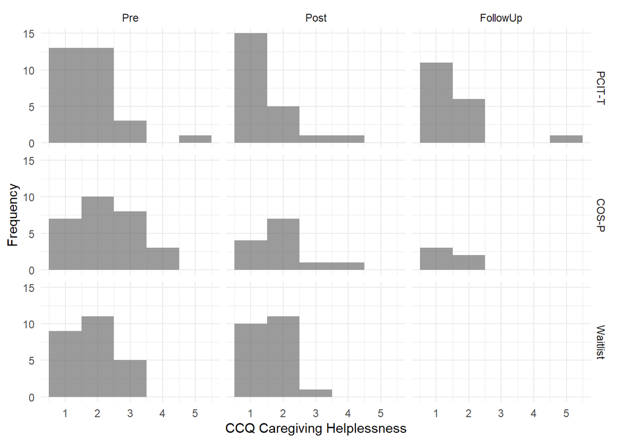

#### Model & Results

A linear mixed model with random effect for individual and fixed effects of group, time and the interaction was run. ASD status was then entered into the model as a main effect and then the 3-way interaction. Estimated marginal means were obtained, and contrasts specified to test Hypothesis 1 and Hypothesis 2.

```
## fixed-effect model matrix is rank deficient so dropping 1 column / coefficient
```

```
## fixed-effect model matrix is rank deficient so dropping 3 columns / coefficients
```

```
## refitting model(s) with ML (instead of REML)
```

[output not shown]

Model3, the model with Group*Time, adjusted by ASD will be the model I use for Estimated Means.

```r
summary(result3)
```

```
## Linear mixed model fit by REML. t-tests use Satterthwaite's method [
## lmerModLmerTest]
## Formula: outcome ~ asdcase + group * time + (1 | id)
##    Data: dat
##
## REML criterion at convergence: 330.5
##
## Scaled residuals:
##     Min      1Q  Median      3Q     Max
## -1.4249 -0.5249 -0.1018  0.4109  2.3184
##
## Random effects:
##  Groups   Name        Variance Std.Dev.
##  id       (Intercept) 0.3865   0.6217
##  Residual             0.1892   0.4350
## Number of obs: 163, groups:  id, 85
##
## Fixed effects:
##               Estimate Std. Error        df t value Pr(>|t|)
## (Intercept)    1.80167    0.14496 104.37893  12.428   <2e-16 ***
## asdcase1       0.27734    0.21350  80.71459   1.299   0.1976
## group2         0.42014    0.20037 106.55425   2.097   0.0384 *
## group3         0.08888    0.20386 109.68408   0.436   0.6637
## time2         -0.27268    0.12786  81.61134  -2.133   0.0360 *
## time3         -0.29641    0.13800  82.36508  -2.148   0.0347 *
## group2:time2  -0.11855    0.20711  86.41087  -0.572   0.5685
## group3:time2  -0.04316    0.18527  82.28341  -0.233   0.8164
## group2:time3  -0.18519    0.27976  86.84911  -0.662   0.5097
## ---
## Signif. codes:  0 '***' 0.001 '**' 0.01 '*' 0.05 '.' 0.1 ' ' 1
##
## Correlation of Fixed Effects:
##             (Intr) asdcs1 group2 group3 time2  time3  grp2:2 grp3:2
## asdcase1    -0.295
## group2      -0.690  0.099
## group3      -0.664  0.049  0.475
## time2       -0.337 -0.012  0.245  0.241
## time3       -0.307 -0.027  0.225  0.223  0.427
## group2:tim2  0.212 -0.008 -0.316 -0.150 -0.617 -0.263
## group3:tim2  0.224  0.037 -0.166 -0.380 -0.691 -0.296  0.426
## group2:tim3  0.148  0.025 -0.231 -0.109 -0.211 -0.494  0.337  0.146
## fit warnings:
## fixed-effect model matrix is rank deficient so dropping 1 column / coefficient
```

#### Estimated Means & Change

Estimated means for each Treatment and Time (adjusted by ASD status) are presented. In addition, within-group change between time points is presented with 95% CIs.

##### Group mean difference at each timepoint

Effect sizes all calculated by the pooled T1 SD of the outcome. Adjusted p-value from Bonferroni correction.

Group Differences at Each Time Point

| Group Difference | Time | Mean | SE | t | p | adj p | Lower CL | Upper CL | Effect Size | Lower CL | Upper CL |
| --- | --- | --- | --- | --- | --- | --- | --- | --- | --- | --- | --- |
| 1 - 2 | 1 | -0.420 | 0.200 | -2.097 | 0.095 | 0.115 | -0.897 | 0.056 | -0.498 | -1.084 | -0.003 |
| 1 - 3 | 1 | -0.089 | 0.204 | -0.436 | 0.901 | 1.000 | -0.573 | 0.396 | -0.105 | -0.595 | 0.403 |
| 2 - 3 | 1 | 0.331 | 0.207 | 1.599 | 0.251 | 0.339 | -0.161 | 0.824 | 0.393 | -0.126 | 0.917 |
| 1 - 2 | 2 | -0.302 | 0.239 | -1.262 | 0.419 | 0.627 | -0.868 | 0.264 | -0.358 | -1.086 | 0.301 |
| 1 - 3 | 2 | -0.046 | 0.218 | -0.210 | 0.976 | 1.000 | -0.562 | 0.470 | -0.054 | -0.623 | 0.509 |
| 2 - 3 | 2 | 0.256 | 0.240 | 1.064 | 0.538 | 0.868 | -0.314 | 0.826 | 0.303 | -0.293 | 0.998 |
| 1 - 2 | 3 | -0.235 | 0.305 | -0.770 | 0.722 | 1.000 | -0.957 | 0.487 | -0.279 | -1.074 | 0.523 |
| 1 - 3 | 3 | NA | NA | NA | NA | NA | NA | NA | NA | NA | NA |
| 2 - 3 | 3 | NA | NA | NA | NA | NA | NA | NA | NA | NA | NA |

* Effect size scaled by pooled T1 SD  
† ES 95% Bootstrapped Percentile CI limits  
‡ If you want a positive ES (and it is calculated as negative), be sure to switch the signs and positions of the lower and upper CIs.

##### Change within each group

Within-Group Change and Effect Sizes

| Change | Group | Mean | SE | t | p | adj p | Lower CL | Upper CL | Effect Size | Lower CL | Upper CL |
| --- | --- | --- | --- | --- | --- | --- | --- | --- | --- | --- | --- |
| 1 - 2 | 1 | 0.273 | 0.128 | 2.129 | 0.090 | 0.109 | -0.033 | 0.579 | 0.323 | 0.045 | 0.706 |
| 1 - 3 | 1 | 0.296 | 0.138 | 2.144 | 0.088 | 0.105 | -0.034 | 0.627 | 0.351 | 0.031 | 0.780 |
| 2 - 3 | 1 | 0.024 | 0.143 | 0.166 | 0.985 | 1.000 | -0.317 | 0.365 | 0.028 | -0.337 | 0.411 |
| 1 - 2 | 2 | 0.391 | 0.164 | 2.392 | 0.049 | 0.057 | 0.001 | 0.781 | 0.464 | 0.127 | 0.953 |
| 1 - 3 | 2 | 0.482 | 0.244 | 1.972 | 0.125 | 0.155 | -0.101 | 1.064 | 0.571 | 0.051 | 1.227 |
| 2 - 3 | 2 | 0.090 | 0.249 | 0.363 | 0.930 | 1.000 | -0.505 | 0.685 | 0.107 | -0.413 | 0.737 |
| 1 - 2 | 3 | 0.316 | 0.134 | 2.352 | 0.054 | 0.063 | -0.005 | 0.636 | 0.374 | 0.066 | 0.822 |
| 1 - 3 | 3 | NA | NA | NA | NA | NA | NA | NA | NA | NA | NA |
| 2 - 3 | 3 | NA | NA | NA | NA | NA | NA | NA | NA | NA | NA |

* Effect size scaled by pooled T1 SD  
† ES 95% Bootstrapped Percentile CI limits  
‡ If you want a positive ES (and it is calculated as negative), be sure to switch the signs and positions of the lower and upper CIs.

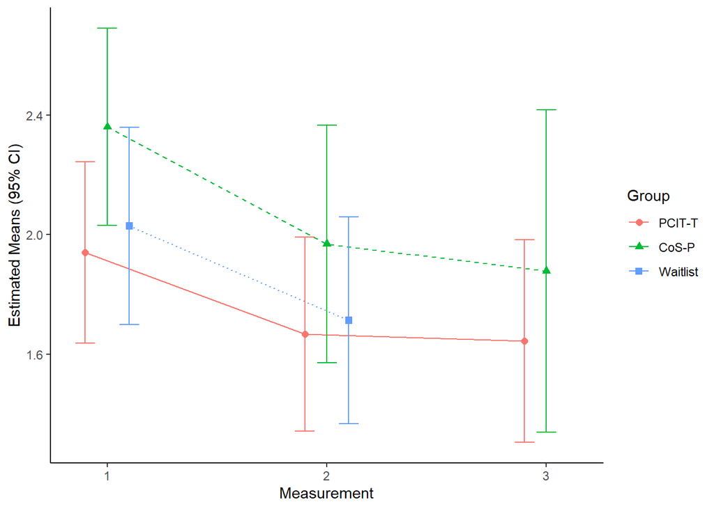

#### Hypothesis 1

We hypothesize that from baseline (‘T1’) to post-treatment/waitlist (‘T2’) there will be a gradient effect, whereby parent-child dyads who receive PCIT-T will show the greatest gains and parent-child dyads who receive no treatment will show the least gains. For the outcome, then, the null hypothesis is:

$H_0: \text {mean change}(\text{PCIT-T}) = \text {mean change}(\text{CoS-P}) = \text {mean change}(\text{Waitlist})$ $H_A: \text {mean change}(\text{PCIT-T}) > \text {mean change}(\text{CoS-P}) > \text {mean change}(\text{Waitlist})$

This is a joint hypothesis test.

```
## group = 1:
##  contrast estimate    SE   df t.ratio p.value
##  1 - 2      0.2727 0.128 79.2   2.129  0.0905
##  1 - 3      0.2964 0.138 80.0   2.144  0.0875
##  2 - 3      0.0237 0.143 76.1   0.166  0.9848
##
## group = 2:
##  contrast estimate    SE   df t.ratio p.value
##  1 - 2      0.3912 0.164 87.1   2.392  0.0491
##  1 - 3      0.4816 0.244 86.1   1.972  0.1254
##  2 - 3      0.0904 0.249 79.5   0.363  0.9301
##
## group = 3:
##  contrast estimate    SE   df t.ratio p.value
##  1 - 2      0.3158 0.134 80.6   2.352  0.0544
##  1 - 3      nonEst    NA   NA      NA      NA
##  2 - 3      nonEst    NA   NA      NA      NA
##
## Results are averaged over the levels of: asdcase
## Degrees-of-freedom method: kenward-roger
## P value adjustment: tukey method for comparing a family of 3 estimates
```

Now, to get the p-value associated with the joint hypothesis.

```
##   (Intercept) asdcase1 group2 group3 time2 time3 group2:time2 group3:time2
## 1           0        0      0      0     0     0           -1            0
## 2           0        0      0      0     0     1            0            1
##   group2:time3
## 1            0
## 2            0
```

```
##
##   General Linear Hypotheses
##
## Linear Hypotheses:
##        Estimate
## 1 == 0   0.1186
## 2 == 0  -0.3396
##
## Global Test:
##       F DF1 DF2 Pr(>F)
## 1 1.527   2 152 0.2204
```

p>0.05, so this joint null hypothesis is not rejected.

#### Hypothesis 2

There will be a gradient of size of change from T2 to T3 such that the change in the PCIT-T group > the change in the CoS-P group. This isn’t really a gradient; it’s just 1 hypothesis.

First, the change in PCITT and COSP from time 2 to time 3:

```
## group = 1:
##  contrast estimate    SE   df t.ratio p.value
##  1 - 2      0.2727 0.128 79.2   2.129  0.0905
##  1 - 3      0.2964 0.138 80.0   2.144  0.0875
##  2 - 3      0.0237 0.143 76.1   0.166  0.9848
##
## group = 2:
##  contrast estimate    SE   df t.ratio p.value
##  1 - 2      0.3912 0.164 87.1   2.392  0.0491
##  1 - 3      0.4816 0.244 86.1   1.972  0.1254
##  2 - 3      0.0904 0.249 79.5   0.363  0.9301
##
## group = 3:
##  contrast estimate    SE   df t.ratio p.value
##  1 - 2      0.3158 0.134 80.6   2.352  0.0544
##  1 - 3      nonEst    NA   NA      NA      NA
##  2 - 3      nonEst    NA   NA      NA      NA
##
## Results are averaged over the levels of: asdcase
## Degrees-of-freedom method: kenward-roger
## P value adjustment: tukey method for comparing a family of 3 estimates
```

```
##
##   Simultaneous Tests for General Linear Hypotheses
##
## Fit: lmer(formula = outcome ~ asdcase + group * time + (1 | id), data = dat)
##
## Linear Hypotheses:
##        Estimate Std. Error z value Pr(>|z|)
## 1 == 0 -0.06664    0.28657  -0.233    0.816
## (Adjusted p values reported -- single-step method)
```

p>0.05.

#### Residuals

Assumptions of the model are met.

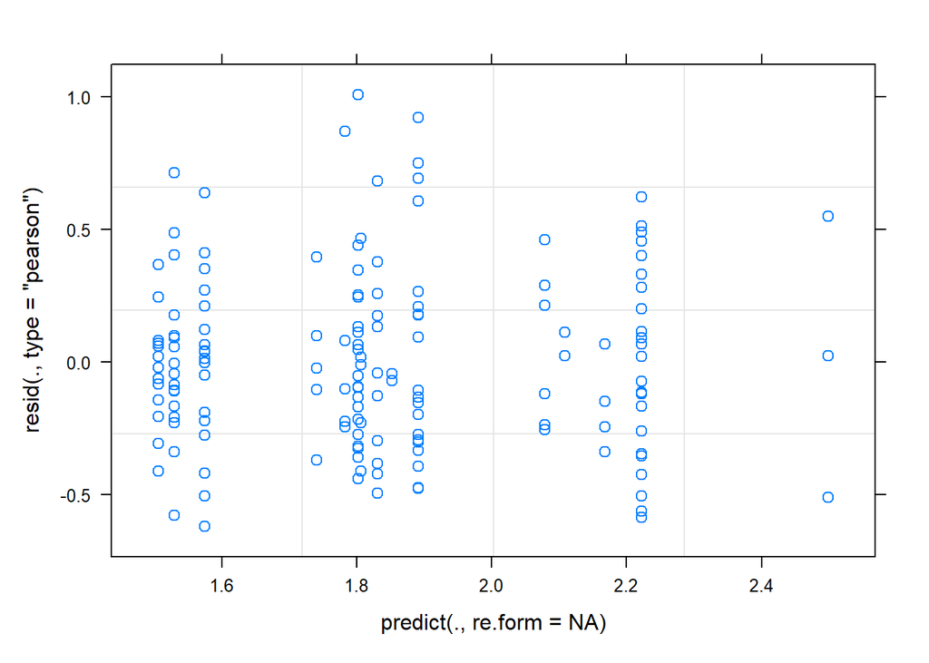

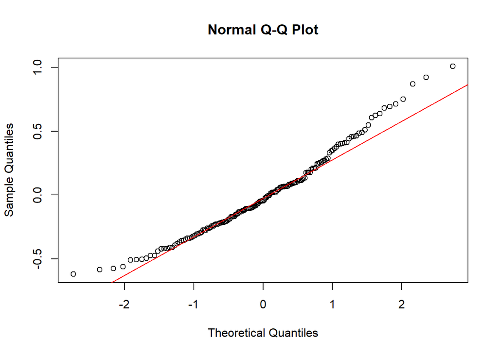

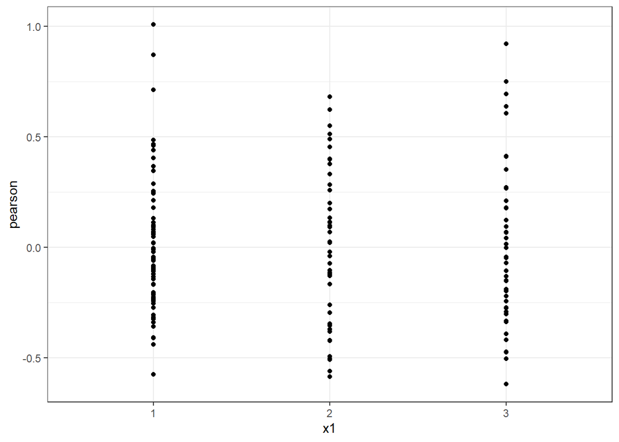

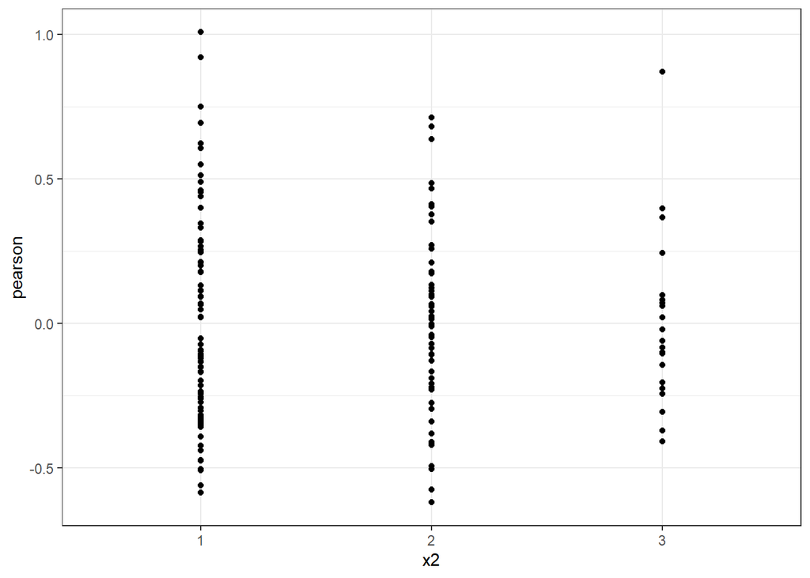

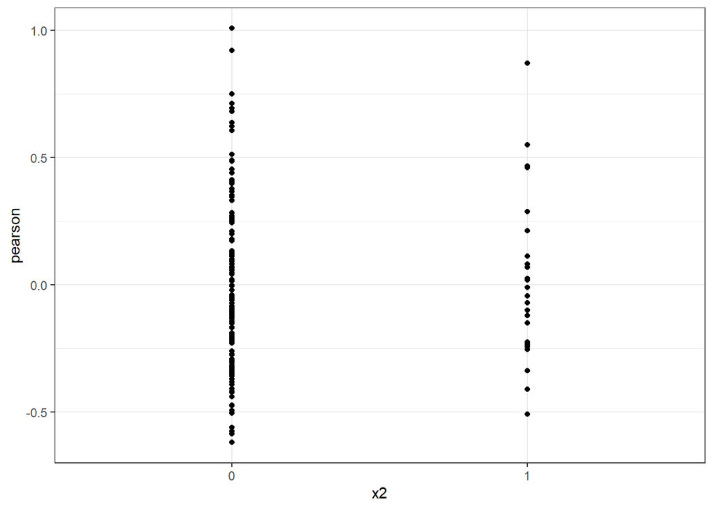

```r
rm(list = ls())
```